# brain

Evangeline Reynolds

11/4/2022

## Problem: positioning with SF feels spooky and data prep can feel effortful

W/ ggplot2, we are able to say ‘where’ with x and y. These are positional aesthetics. With SF the ‘where’ is implied with the geometry column. This feels non-declarative and spooky to me.

Also, it often requires pre-processing to work with data you’d like to represent.

When we ask the question ‘where’ in a geographical context, a human being will respond with the name of a region; not coordinates and not a set of coordinates that define a region. Is it possible to create an interface where you define ‘where’ with geographical names or other ids? For example: `aes(country = my_countries_variable)` could be used with a geom/stat like geom_polygon_countries().

```r
library(tidyverse)
```

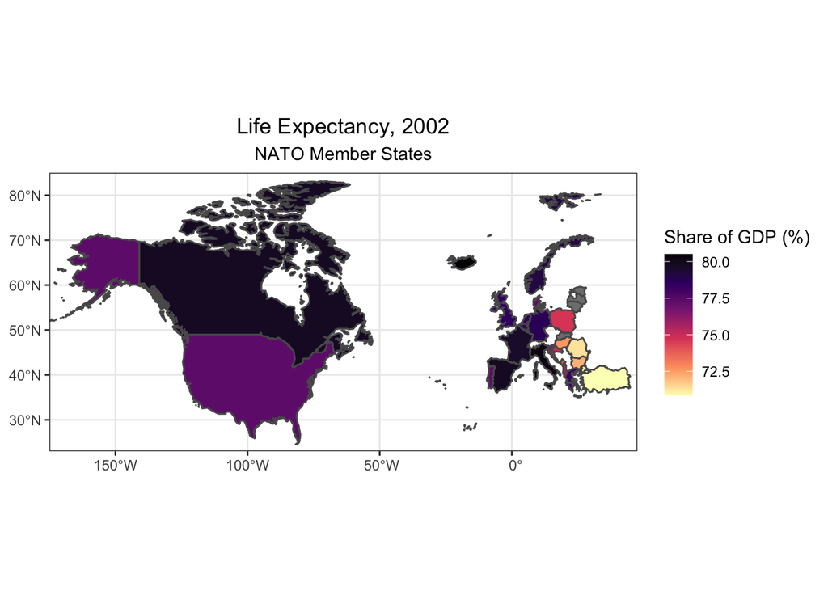

```r
nato_names <- c("Albania", "Belgium", "Bulgaria", "Canada", "Croatia", "Czech Republic", "Denmark", "Estonia", "France", "Germany", "Greece", "Hungary",
                "Iceland", "Italy", "Latvia", "Lithuania", "Luxembourg", "Montenegro", "Netherlands", "Norway", "Poland", "Portugal", "Romania", "Slovakia", "Slovenia", "Spain", "Turkey", "United Kingdom", "United States")
library(gapminder)
gapminder %>%
  filter(year == 2002) %>%
  rename(name = country) ->
gapminder_2002_prepped

rnaturalearth::ne_countries(scale = "medium", returnclass = "sf") %>%
  select(name, pop_est, gdp_md_est,
         continent, geometry) %>%
  filter(name %in% nato_names) %>%
  left_join(gapminder_2002_prepped, by = "name") ->
  nato_countries

ggplot(data = nato_countries) +
  # This part feels spooky to me
  ggplot2::geom_sf(data = nato_countries) +
    aes(fill = lifeExp) +
    scale_fill_viridis_c(option = "magma", direction = -1) +
  ggplot2::coord_sf(xlim = c(-175, 47.5),
           ylim = c(23, 85),
           expand = FALSE) +
  labs(title = "Life Expectancy, 2002",
         subtitle = "NATO Member States",
         fill = "Share of GDP (%)") +
  theme_bw() +
  theme(plot.title =
            element_text(hjust = 0.5)) +
  theme(plot.subtitle =
            element_text(hjust = 0.5))
```

See step-by-step: https://evamaerey.github.io/ggplot2_grammar_guide/geom_sf.html#1

# Wait, why is this project called ‘brain’?

One inspiration for this is ggseg too. Very cool project that uses sf spatial approach. I wonder if there’d be a version where regions of the brain could be simply named, and other aesthetics defined. Motivated by how I’d like to learn more about the regions of the brain! :-)

## A different API?

Here is what I think might be an easy to use API.

```
ggworld(data = gapminder_2002, projection = 'a good one') +
  aes(country = country, # positioning aesthetic
      fill = lifeExp) +
  geom_polygon_country()
```

# Proof of concept? (without SF)

Because of my limited knowledge of SF, let’s start w/ the x and y inputs approach to mapping with ggplot2 and see if we can cook something up.

## Step 00: See how someone gets it done

I was here: https://remiller1450.github.io/s230s19/Intro_maps.html

## Step 0: get it done w/ ggplot2

Look at mapping w/ ggplot2, no sf, we use geom_polygon and the x, y and group aesthetics). It is not very efficient (lots of redundant info in the ), but we won’t worry about that for this demonstration. A little rewrite to get inspired.

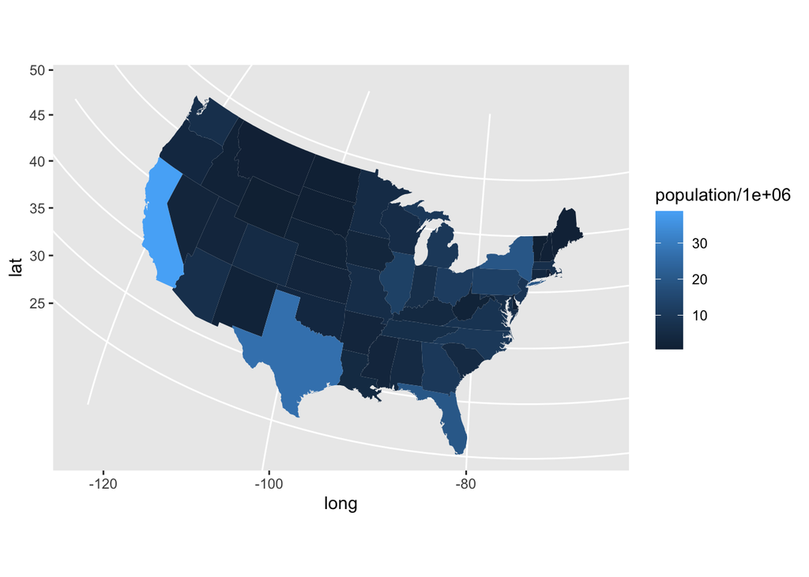

```r
library(ggplot2)
library(dplyr)
library(maps)
MainStates <- map_data("state")
StatePopulation <- read.csv("https://raw.githubusercontent.com/ds4stats/r-tutorials/master/intro-maps/data/StatePopulation.csv", as.is = TRUE)

MergedStates <- inner_join(MainStates, StatePopulation, by = "region")

StatePopulation %>% # becomes ggus()
  right_join(MainStates) %>% # becomes ggus()
  ggplot() + # becomes ggus()
  geom_polygon() + # becomes geom_polygon state
  aes(x = long, # becomes state = region
      y = lat, # becomes state = region
      group = group, # becomes state = region
      fill = population/1000000) +
  coord_map(projection = "orthographic",
            orientation = c(41, -74, 0))
```

# Step 1: compute function and test

```r
library(maps)
MainStates <- map_data("state")
# AllCounty <- map_data("county")
# MainCities <- filter(us.cities, long>=-130)

StatePopulation <- read.csv("https://raw.githubusercontent.com/ds4stats/r-tutorials/master/intro-maps/data/StatePopulation.csv", as.is = TRUE)

compute_state <- function(data, scales){

  data %>%
    inner_join(map_data("state") %>% rename(state = region)) %>%
    mutate(x = long, y = lat) %>%
    mutate(group = group)

}

StatePopulation %>%
  rename(state = region) %>%
  compute_state() ->
computed
str(computed)
```

```
## 'data.frame':    15527 obs. of  10 variables:
##  $ state      : chr  "alabama" "alabama" "alabama" "alabama" ...
##  $ population : int  4849377 4849377 4849377 4849377 4849377 4849377 4849377 4849377 4849377 4849377 ...
##  $ elect_votes: int  9 9 9 9 9 9 9 9 9 9 ...
##  $ long       : num  -87.5 -87.5 -87.5 -87.5 -87.6 ...
##  $ lat        : num  30.4 30.4 30.4 30.3 30.3 ...
##  $ group      : num  1 1 1 1 1 1 1 1 1 1 ...
##  $ order      : int  1 2 3 4 5 6 7 8 9 10 ...
##  $ subregion  : chr  NA NA NA NA ...
##  $ x          : num  -87.5 -87.5 -87.5 -87.5 -87.6 ...
##  $ y          : num  30.4 30.4 30.4 30.3 30.3 ...
```

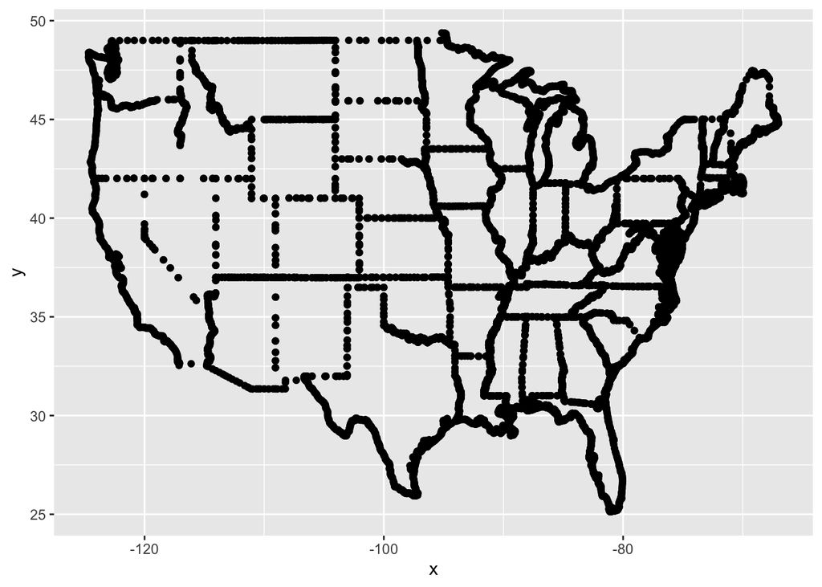

```r
computed %>%
  ggplot() +
  aes(x = x, y = y) +
  geom_point()
```

```r
my_setup_data <- function(data, params){
                                    if(data$group[1] == -1){
                                      nrows <- nrow(data)
                                      data$group <- seq_len(nrows)
                                    }
                                    data
}
```

# Step 2: pass to ggproto

```r
StatPolygonstate <- ggplot2::ggproto(`_class` = "StatPolygonstate",
                                  `_inherit` = ggplot2::Stat,
                                  required_aes = c("state"),
                                  compute_panel = compute_state#,
                                   # setup_data = my_setup_data
                                  # default_aes = aes(group = after_stat(state))
                                  )
```

# Step 3: write geom_* function

```r
geom_polygon_state <- function(
  mapping = NULL,
  data = NULL,
  position = "identity",
  na.rm = FALSE,
  show.legend = NA,
  inherit.aes = TRUE, ...) {
  ggplot2::layer(
    stat = StatPolygonstate,  # proto object from step 2
    geom = ggplot2::GeomPolygon,  # inherit other behavior
    data = data,
    mapping = mapping,
    position = position,
    show.legend = show.legend,
    inherit.aes = inherit.aes,
    params = list(na.rm = na.rm, ...)
  )
}
```

# step 4: test geom_* function, celebrate!

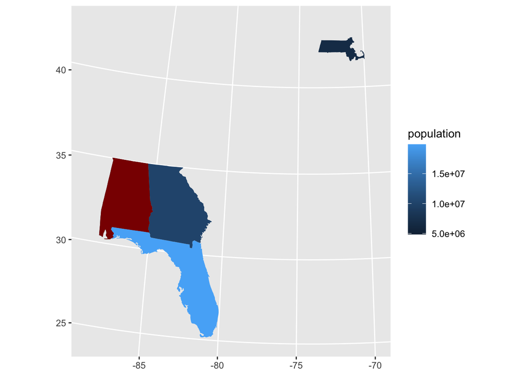

```r
StatePopulation %>%
  mutate(region = as.factor(region)) %>%
ggplot(data = .) +
  aes(state = region, # state indicates position instead of x and y
      fill = population) +
  geom_polygon_state() +
  coord_map() +
  geom_polygon_state(data = . %>%
                       filter(region == "alabama"),
                     fill = "darkred" ) +
  coord_map(projection = "orthographic",
            orientation = c(41, -74, 0))
```

# Step 5: What’s not working and taking a break.

1. Not sure what’s going on w/ merge so that we only get the 4 states.
2. state = var, var must be factor (not character). I’ve seen this before and I’d like that not to be the case, but fine for now.
3. We are celebrating in spite of 1 and 2! And putting aside.

```r
StatePopulation %>% distinct(region) %>% pull()
```

```
##  [1] "alabama"        "alaska"         "arizona"        "arkansas"
##  [5] "california"     "colorado"       "connecticut"    "delaware"
##  [9] "florida"        "georgia"        "hawaii"         "idaho"
## [13] "illinois"       "indiana"        "iowa"           "kansas"
## [17] "kentucky"       "louisiana"      "maine"          "maryland"
## [21] "massachusetts"  "michigan"       "minnesota"      "mississippi"
## [25] "missouri"       "montana"        "nebraska"       "nevada"
## [29] "new hampshire"  "new jersey"     "new mexico"     "new york"
## [33] "north carolina" "north dakota"   "ohio"           "oklahoma"
## [37] "oregon"         "pennsylvania"   "rhode island"   "south carolina"
## [41] "south dakota"   "tennessee"      "texas"          "utah"
## [45] "vermont"        "virginia"       "washington"     "west virginia"
## [49] "wisconsin"      "wyoming"
```

# 0 County

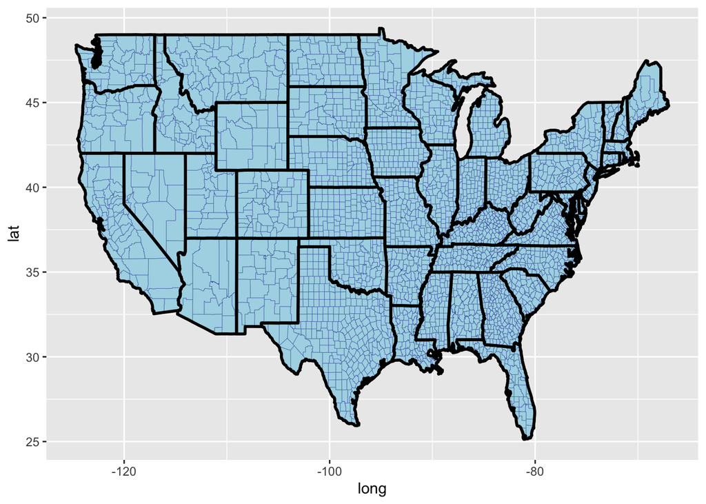

```r
AllCounty <- map_data("county")
ggplot() + geom_polygon( data=AllCounty, aes(x=long, y=lat, group=group),
                color="darkblue", fill="lightblue", size = .1 ) +

          geom_polygon( data=MainStates, aes(x=long, y=lat, group=group),
                color="black", fill="lightblue",  size = 1, alpha = .3)
```

# Circle pack seems similar…

https://evamaerey.github.io/mytidytuesday/2022-05-28-circle-pack/circle_pack_stipple.html